# Getting into flow cyto analysis in R, basics

Darach Miller

2016-05-10

I believe you should compartamentalize your reading in from files and your analysis. You should use the below script is just to yank it in, and spit it out as a CSV.

Below is just the directory where my FCS files are.

```r
directories <- c(
    exp154sytoxgreen="/home/zed/lab/data/mine/1601/exp154sytoxgreen/"
  )
directories
```

```
##                                 exp154sytoxgreen
## "/home/zed/lab/data/mine/1601/exp154sytoxgreen/"
```

```r
dir(directories[1])
```

```
##  [1] "A01 g1_neg_neg.fcs"             "A01 g1_sytoxgreen_pk.fcs"
##  [3] "A02 g2_neg_neg.fcs"             "A02 g2_sytoxgreen_pk.fcs"
##  [5] "A03 g3_neg_neg.fcs"             "A03 g3_sytoxgreen_pk.fcs"
##  [7] "A04 g4_neg_neg.fcs"             "A04 g4_sytoxgreen_pk.fcs"
##  [9] "A05 g5_neg_neg.fcs"             "A05 g5_sytoxgreen_pk.fcs"
## [11] "A06 g6_neg_neg.fcs"             "A06 g6_sytoxgreen_pk.fcs"
## [13] "B01 11_neg_neg.fcs"             "B01 11_sytoxgreen_pk.fcs"
## [15] "B02 12_neg_neg.fcs"             "B02 12_sytoxgreen_pk.fcs"
## [17] "B03 13_neg_neg.fcs"             "B03 13_sytoxgreen_pk.fcs"
## [19] "B04 14_neg_neg.fcs"             "B04 14_sytoxgreen_pk.fcs"
## [21] "B05 15_neg_neg.fcs"             "B05 15_sytoxgreen_pk.fcs"
## [23] "B06 16_neg_neg.fcs"             "B06 16_sytoxgreen_pk.fcs"
## [25] "C01 g1_sytoxgreen_rnase_pk.fcs" "C02 g2_sytoxgreen_rnase_pk.fcs"
## [27] "C03 g3_sytoxgreen_rnase_pk.fcs" "C04 g4_sytoxgreen_rnase_pk.fcs"
## [29] "C05 g1_sytoxgreen_neg.fcs"      "C05 g5_sytoxgreen_rnase_pk.fcs"
## [31] "C06 14_sytoxgreen_neg.fcs"      "C06 g6_sytoxgreen_rnase_pk.fcs"
## [33] "D01 11_sytoxgreen_rnase_pk.fcs" "D02 12_sytoxgreen_rnase_pk.fcs"
## [35] "D03 13_sytoxgreen_rnase_pk.fcs" "D04 14_sytoxgreen_rnase_pk.fcs"
## [37] "D05 15_sytoxgreen_rnase_pk.fcs" "D06 16_sytoxgreen_rnase_pk.fcs"
```

See how that works? Change it to where your stuff is. Name it according to the experiment name.

Here we immediately use `flowCore` just to extract the measurements from the machine. Note the lack of any confounding transformation. This is 2016, and I’m pretty sure these are linear digital detectors.

```r
require(flowCore)
datz <- list()
for (expr in names(directories)) {
  dirz <- directories[expr]
  for (fz in dir(dirz)[grep("\\.fcs$",dir(dirz))]) {
    nameToSaveAs <- paste0(expr, warning=F,"_",sub(".fcs","",fz))
    print(paste0("doing ",dirz,"",fz,", saving it as ",nameToSaveAs))
    datz[[nameToSaveAs]] <- data.frame(
        exprs(read.FCS(paste0(dirz,fz),transformation=FALSE))
      )
  }
}
```

```
## [1] "doing /home/zed/lab/data/mine/1601/exp154sytoxgreen/A01 g1_neg_neg.fcs, saving it as exp154sytoxgreenFALSE_A01 g1_neg_neg"
## [1] "doing /home/zed/lab/data/mine/1601/exp154sytoxgreen/A01 g1_sytoxgreen_pk.fcs, saving it as exp154sytoxgreenFALSE_A01 g1_sytoxgreen_pk"
## [1] "doing /home/zed/lab/data/mine/1601/exp154sytoxgreen/A02 g2_neg_neg.fcs, saving it as exp154sytoxgreenFALSE_A02 g2_neg_neg"
## [1] "doing /home/zed/lab/data/mine/1601/exp154sytoxgreen/A02 g2_sytoxgreen_pk.fcs, saving it as exp154sytoxgreenFALSE_A02 g2_sytoxgreen_pk"
## [1] "doing /home/zed/lab/data/mine/1601/exp154sytoxgreen/A03 g3_neg_neg.fcs, saving it as exp154sytoxgreenFALSE_A03 g3_neg_neg"
## [1] "doing /home/zed/lab/data/mine/1601/exp154sytoxgreen/A03 g3_sytoxgreen_pk.fcs, saving it as exp154sytoxgreenFALSE_A03 g3_sytoxgreen_pk"
## [1] "doing /home/zed/lab/data/mine/1601/exp154sytoxgreen/A04 g4_neg_neg.fcs, saving it as exp154sytoxgreenFALSE_A04 g4_neg_neg"
## [1] "doing /home/zed/lab/data/mine/1601/exp154sytoxgreen/A04 g4_sytoxgreen_pk.fcs, saving it as exp154sytoxgreenFALSE_A04 g4_sytoxgreen_pk"
## [1] "doing /home/zed/lab/data/mine/1601/exp154sytoxgreen/A05 g5_neg_neg.fcs, saving it as exp154sytoxgreenFALSE_A05 g5_neg_neg"
## [1] "doing /home/zed/lab/data/mine/1601/exp154sytoxgreen/A05 g5_sytoxgreen_pk.fcs, saving it as exp154sytoxgreenFALSE_A05 g5_sytoxgreen_pk"
## [1] "doing /home/zed/lab/data/mine/1601/exp154sytoxgreen/A06 g6_neg_neg.fcs, saving it as exp154sytoxgreenFALSE_A06 g6_neg_neg"
## [1] "doing /home/zed/lab/data/mine/1601/exp154sytoxgreen/A06 g6_sytoxgreen_pk.fcs, saving it as exp154sytoxgreenFALSE_A06 g6_sytoxgreen_pk"
## [1] "doing /home/zed/lab/data/mine/1601/exp154sytoxgreen/B01 11_neg_neg.fcs, saving it as exp154sytoxgreenFALSE_B01 11_neg_neg"
## [1] "doing /home/zed/lab/data/mine/1601/exp154sytoxgreen/B01 11_sytoxgreen_pk.fcs, saving it as exp154sytoxgreenFALSE_B01 11_sytoxgreen_pk"
## [1] "doing /home/zed/lab/data/mine/1601/exp154sytoxgreen/B02 12_neg_neg.fcs, saving it as exp154sytoxgreenFALSE_B02 12_neg_neg"
```

[output cut: 23 more lines]

The below takes everything in `datz` and `rbind()`’s it together to make one large data frame. This might take a while.

```r
if (exists("lrgdf")) {rm(lrgdf)}
for (fz in names(datz)) {
  relevantBit <- gsub(".+?\\s(.+?)$","\\1",fz)
  tmpdf <- data.frame(datz[[as.character(fz)]],
    colsplit(relevantBit,"_",names=c("sample","dye","pretreatment")))
  if (!exists("lrgdf")) { lrgdf <- tmpdf }
  else { lrgdf <- rbind(lrgdf,tmpdf) }
}
dim(lrgdf)
```

```
## [1] 1508803      17
```

```r
head(lrgdf)
```

```
##     FSC.A  SSC.A FL1.A FL2.A FL3.A FL4.A   FSC.H  SSC.H FL1.H FL2.H FL3.H
## 1  709972  83167   424   340  1215   745  990991 114553  1272   230  2234
## 2 1198162 306662     0   836     0     0 1420102 340219  1052   271  1798
## 3  400629  34351    64    32     0     0  567263  38628   938    84  1415
## 4  911311 155561     0    91     0   264 1108412 181789  1035   126   621
## 5  552332  76397   493   340   995   121  782584 100985  1060   159  1340
## 6  629602 123877   652    67  1985   483  898719 154819   791   142  2356
##   FL4.H Width Time sample dye pretreatment
## 1   838    83  777     g1 neg          neg
## 2   125   115  777     g1 neg          neg
## 3   590    78  777     g1 neg          neg
## 4   439    87  777     g1 neg          neg
## 5   186    78  777     g1 neg          neg
## 6   643    79  777     g1 neg          neg
```

And you can save that as a csv if you’d like:

```r
write.csv(lrgdf,file=paste0(names(directories)[1],"160510.csv"),
  quote=F,row.names=F)
```

Since I’ve got your attention, I’m going to show you how to gate like a neadertal. It works. Note that I’m plotting a random subset of rows in order to make this plot more quickly.

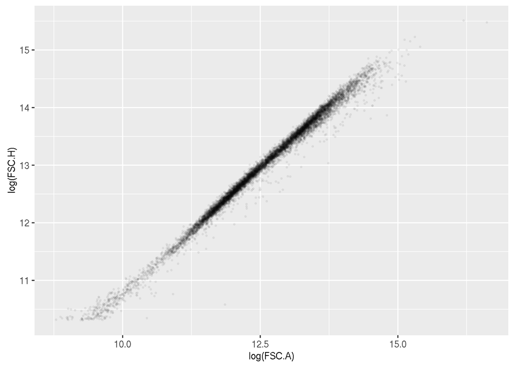

```r
aSubsetOflrgdf <- lrgdf[sample(1:nrow(lrgdf),1e4),]
g <- ggplot(aSubsetOflrgdf)+
  aes(x=log(FSC.A),y=log(FSC.H))+
  geom_point(size=.5,alpha=.05)
g
```

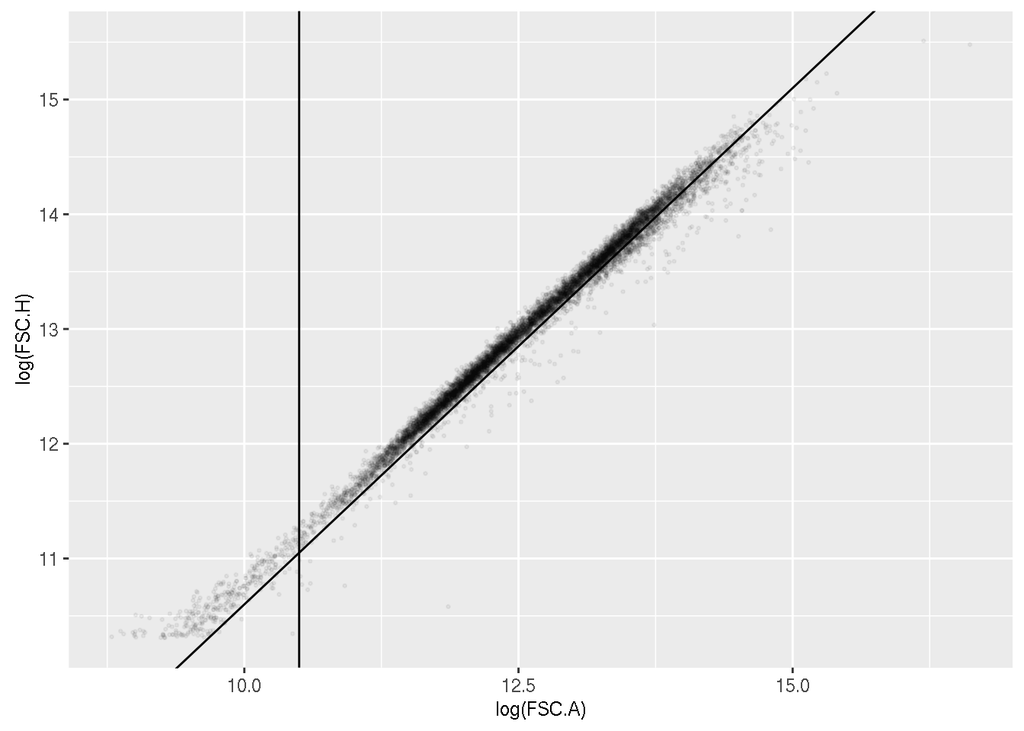

```r
g+geom_vline(xintercept=10.5)+geom_abline(slope=0.9,intercept=1.6)
```

Looks like singlets.

```r
subdf<-subset(lrgdf,log(FSC.A)>10.5&(log(FSC.H)>log(FSC.A)*0.9+1.6))
aSubsetOfsubdf <- subdf[sample(1:nrow(subdf),1e4),]
```

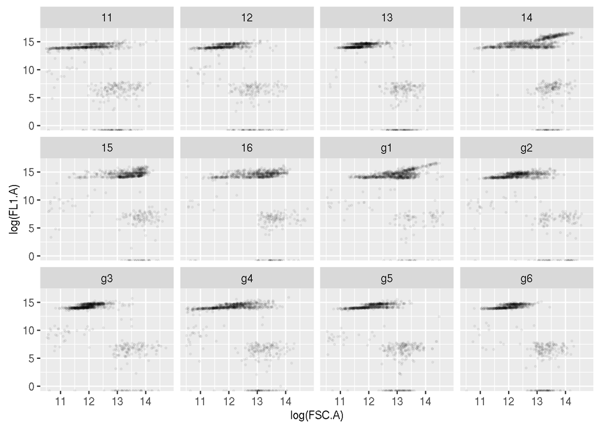

```r
g <- ggplot(aSubsetOfsubdf)+
  aes(x=log(FSC.A),y=log(FL1.A))+
  geom_point(size=.5,alpha=.05)+
  facet_wrap(~sample)
g
```

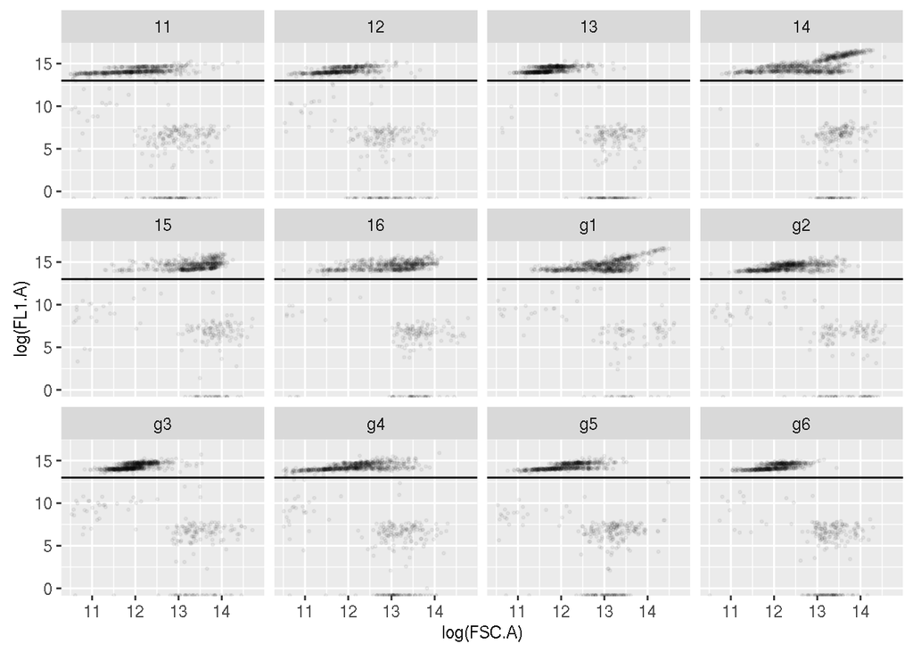

```r
g+geom_hline(yintercept=13)
```

Same thing.

```r
subdf <- subset(subdf,log(FL1.A)>13)
aSubsetOfsubdf <- subdf[sample(1:nrow(subdf),1e4),]
```

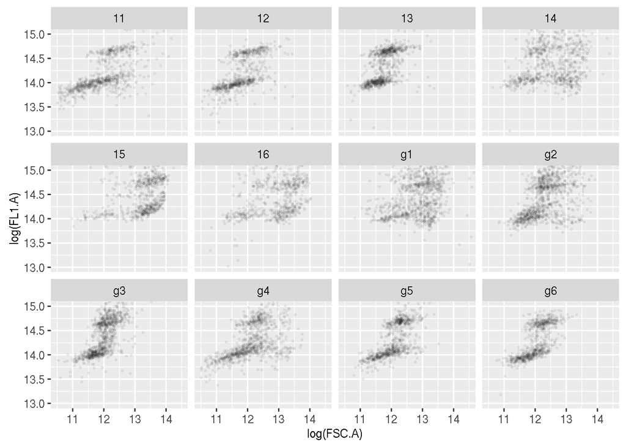

```r
g <- ggplot(aSubsetOfsubdf)+
  aes(x=log(FSC.A),y=log(FL1.A))+
  geom_point(size=.5,alpha=.05)+
  facet_wrap(~sample)
g+coord_cartesian(xlim=c(10.5,14.5),ylim=c(13,15))
```

Close enoguht, although you can see some contamination. Let’s look at that in a different way, this time for all datar.

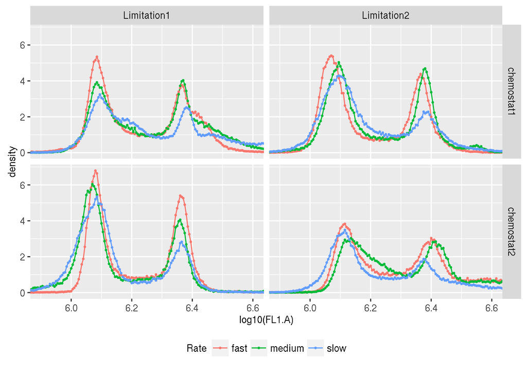

```r
subdf$Machine <- ifelse(grepl("g",subdf$sample),
  "chemostat1","chemostat2")
subdf$Limitation <- ifelse(grepl(".[123]",subdf$sample),
  "Limitation1","Limitation2")
subdf$Rate <- rep(c("slow","medium","fast"),2)[
  as.numeric(sub("^.","",subdf$sample))]
g <- ggplot(subdf)+aes(x=log10(FL1.A),col=Rate)+
  stat_bin(aes(y = ..density..),binwidth=0.005,geom="line",
    position="identity",size=.5)+
  stat_bin(aes(y = ..density..),binwidth=0.005,geom="point",
    position="identity",size=.5)+
  coord_cartesian(xlim=c(5.9,6.6))+
  theme(legend.position="bottom")
g+facet_grid(Machine~Limitation)
```

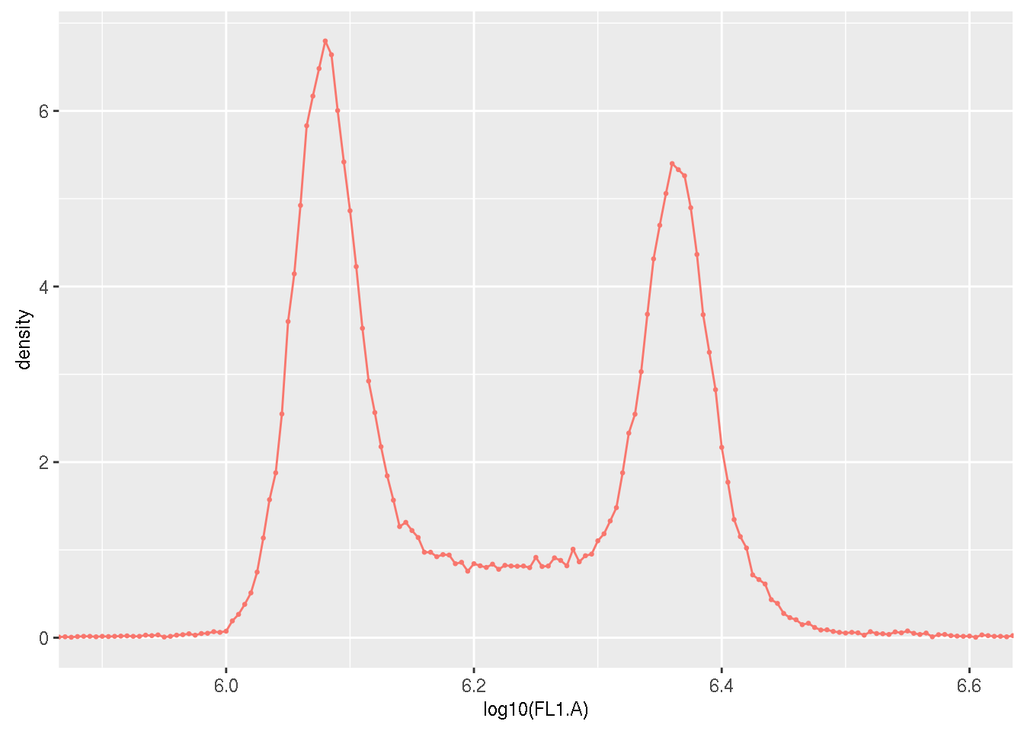

```r
g%+%subset(subdf,Limitation=="Limitation1"&Rate=="fast"&Machine=="chemostat2")+
  guides(col=F)
```

That’s text book.

One of these days, I’ll write up how to use `mle2` to fit a mixed model to estimate cell cycle contribution.

Anyone want to contribute and do this one?